# Prediciendo el número de hijos de los hogares colombianos

## Modelamiento

La mayoría de las variables escogidas como significativas corresponden a variables categóricas, se seleccionaron modelos que permiten el correcto manejo de las mismas. A continuación se ilustra la etapa de modelamiento:

Se realiza un gráfico de barras, para observar como se distribuye el número de hijos en los hogares colombianos.

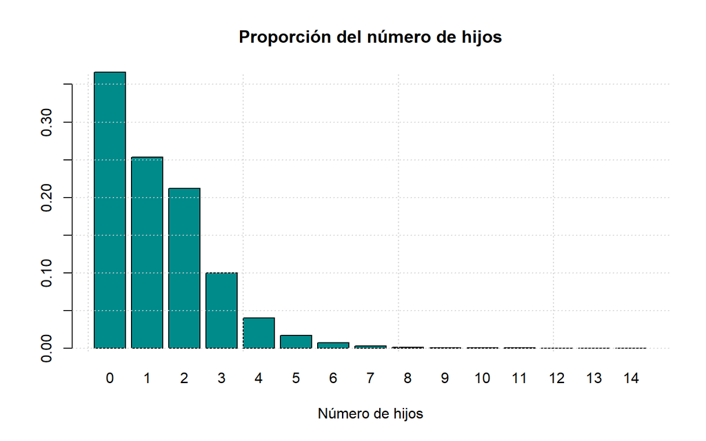

```r
barplot(prop.table(table(Base_modelar$Num_hijos)),
        main = "Proporción del número de hijos",
        xlab = "Número de hijos",
        col = "cyan4")
grid()
```

Además, que en una situación real resulta poco relevante determinar con precisión el número de hijos cuando estos son muchos, ya que con la información de que es una cantidad numerosa de hijos es suficiente para tomar la decisión que se requiera.

```r
Base_de_ensayo <- Base_modelar

# Se agrupa los hogares con 5 hijos o más en una sola categoría
Base_de_ensayo$Num_hijos[Base_de_ensayo$Num_hijos >= 5] <- 5
```

| Número de hijos | Frecuencia |
| --- | --- |
| 0 | 34418 |
| 1 | 23838 |
| 2 | 19896 |
| 3 | 9370 |
| 4 | 3770 |
| 5 o más | 2701 |

### Bosques Aleatorios para selección de variables

Se organiza la base de datos para aplicar el modelo

```r
library(tidyverse)

# Se omiten las filas que poseen NA
Base_modelar_f <- na.omit(Base_de_ensayo)

# Se convierte la variable Num_hijos a factor
Base_modelar_f$Num_hijos <- as.factor(Base_modelar_f$Num_hijos)

set.seed(15234) # Semilla

# Se saca una muestra de entrenamiento que conserve las proporciones en la variable Num_hijos
trn_prop <- Base_modelar_f %>%
  mutate(
    var_indx = 1:dim(Base_modelar_f)[1]
  ) %>%
  group_by(Num_hijos) %>%
  sample_frac(0.8, replace = F)

# Se saca la muestra de test con las que no fueron seleccionadas en la muestra de train
tst_prop <- Base_modelar_f[-trn_prop$var_indx, ]

# Se elimina la variable de indice
trn_prop$var_indx <- NULL
```

Con la función *ranger* aplicamos el modelo de Bosques aleatorios

```r
# Modelo RF
mod_RF <- ranger(
  Num_hijos~.,
  data = (trn_prop),
  num.trees = 500,
  mtry = 5,
  max.depth = 8,
  importance = 'impurity'
)
```

En la siguiente gráfica se muestra las variables que tienen mayor importancia para Bosques aleatorios:

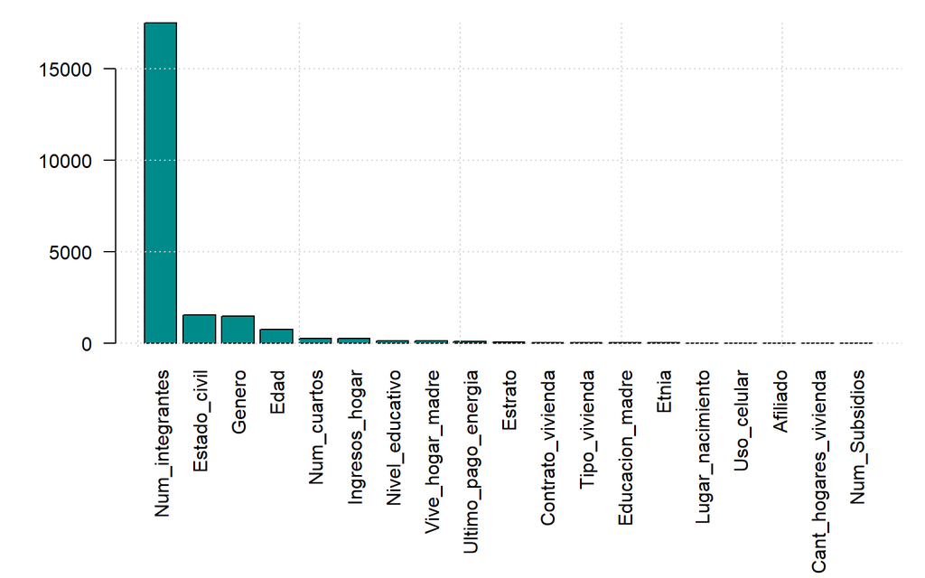

Se utiliza los pesos de importancia asignados por Bosques Aleatorios para escoger las variables que se utilizarán en el resto de modelos, además se tiene en cuenta la cantidad de NA en cada una de las variables.

```r
kable(colSums(is.na(Base_de_ensayo)), align = "c", col.names = "Cantidad de NA") %>%
  kable_paper("striped", full_width =F)
```

|  | Cantidad de NA |
| --- | --- |
| Genero | 0 |
| Edad | 0 |
| Num_integrantes | 0 |
| Num_cuartos | 0 |
| Estrato | 5194 |
| Tipo_vivienda | 0 |
| Num_Subsidios | 0 |
| Educacion_madre | 2181 |
| Estado_civil | 0 |
| Ultimo_pago_energia | 5194 |
| Ingresos_hogar | 0 |
| Cant_hogares_vivienda | 0 |
| Num_hijos | 0 |
| Uso_celular | 9197 |
| Vive_hogar_madre | 0 |
| Contrato_vivienda | 0 |
| Etnia | 0 |
| Afiliado | 0 |
| Lugar_nacimiento | 0 |
| Nivel_educativo | 2366 |

Dado que el anterior modelo fue ajustado eliminando todas las filas con NAs, se procedió a eliminar una a una según el orden de importancia las columnas con NAs y a verificar su impacto en la tasa de acierto en el conjunto de validación.

El resultado que se obtuvo fue que la tasa de acierto levemente aumentó a medida que se excluyeron las columnas con NAs y por ende no se eliminaba ninguna fila del conjunto de entrenamiento.

Por último, en busca de un modelo parsimonioso se ajustó excluyendo una a una las variables restantes (sin NAs) según el orden de importancia en el modelo Random Forest; Donde se tuvo en cuenta que el orden de importancia no se viera dramáticamente afectado de modelo a modelo y que la tasa de acierto no disminuyera drásticamente.

Del resultado anterior se determinó conservar las siguientes 5 variables.

### Variables escogidas

Las variables a utilizar en los modelos son las escogidas en orden de importancia por Bosques Aleatorios, se muestran a continuación:

- Num_integrantes
- Estado_civil
- Genero
- Edad
- Vive_hogar_madre
- Num_hijos

```r
library(tidyverse)

# Variables en orden de importancia según RF
var_imprt <-  c(
    "Num_integrantes",
    "Estado_civil",
    "Genero",
    "Edad",
    "Vive_hogar_madre",
    "Num_hijos"
  )


# Conjunto de datos con las variables importantes
Base_modelar_f <- Base_de_ensayo[,var_imprt]

# Se convierte la variable Num_hijos a factor
Base_modelar_f$Num_hijos <- as.factor(Base_modelar_f$Num_hijos)

set.seed(15234) # Semilla

# Se saca una muestra de entrenamiento que conserve las proporciones en la variable Num_hijos
trn_prop <- Base_modelar_f %>%
  mutate(
    var_indx = 1:dim(Base_modelar_f)[1]
  ) %>%
  group_by(Num_hijos) %>%
  sample_frac(0.8, replace = F)

# Se saca la muestra de test con las que no fueron seleccionadas en la muestra de train
tst_prop <- Base_modelar_f[-trn_prop$var_indx, ]

# Se elimina la variable de indice
trn_prop$var_indx <- NULL
```

### Modelo de Regresión Lineal Múltiple

Se debe convertir la variable respuesta nuevamente a numérica para poder aplicar regresión lineal.

```r
modelo1 <- lm(as.numeric(as.character(Num_hijos))~., data=trn_prop)
```

El error estándar del modelo es 0.5346394

Análisis de residuales.

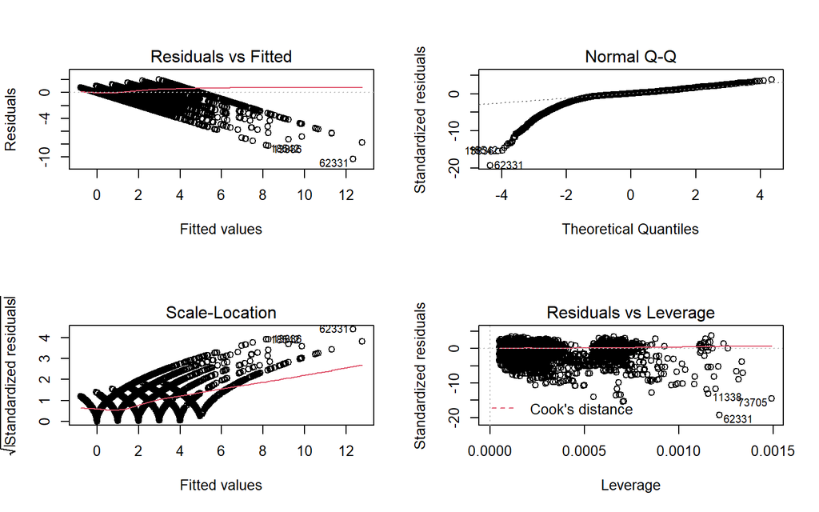

Se puede apreciar que no se cumple el supuesto de normalidad en los residuales, homocedasticidad e independencia, por lo tanto no es adecuado para realizar predicciones.

Matriz de confusión

| Predicciones | Reales 0 | Reales 1 | Reales 2 | Reales 3 | Reales 4 | Reales 5 |
| --- | --- | --- | --- | --- | --- | --- |
| -1 | 122 | 0 | 0 | 0 | 0 | 0 |
| 0 | 5948 | 122 | 0 | 0 | 0 | 0 |
| 1 | 646 | 4143 | 321 | 0 | 0 | 0 |
| 2 | 127 | 409 | 3379 | 758 | 1 | 0 |
| 3 | 32 | 83 | 249 | 1056 | 578 | 4 |
| 4 | 7 | 7 | 19 | 50 | 143 | 215 |
| 5 | 1 | 3 | 7 | 8 | 26 | 200 |
| 6 | 0 | 1 | 3 | 1 | 4 | 67 |
| 7 | 0 | 0 | 0 | 0 | 0 | 25 |
| 8 | 0 | 0 | 1 | 1 | 2 | 21 |
| 9 | 0 | 0 | 0 | 0 | 0 | 4 |
| 10 | 1 | 0 | 0 | 0 | 0 | 0 |
| 11 | 0 | 0 | 0 | 0 | 0 | 1 |
| 12 | 0 | 0 | 0 | 0 | 0 | 2 |
| 13 | 0 | 0 | 0 | 0 | 0 | 1 |

### Árbol de clasificación

Con la función *rpart* se ajusta el modelo y se analizan los resultados

```r
mod1_arboles <- rpart(Num_hijos~., data = trn_prop)
```

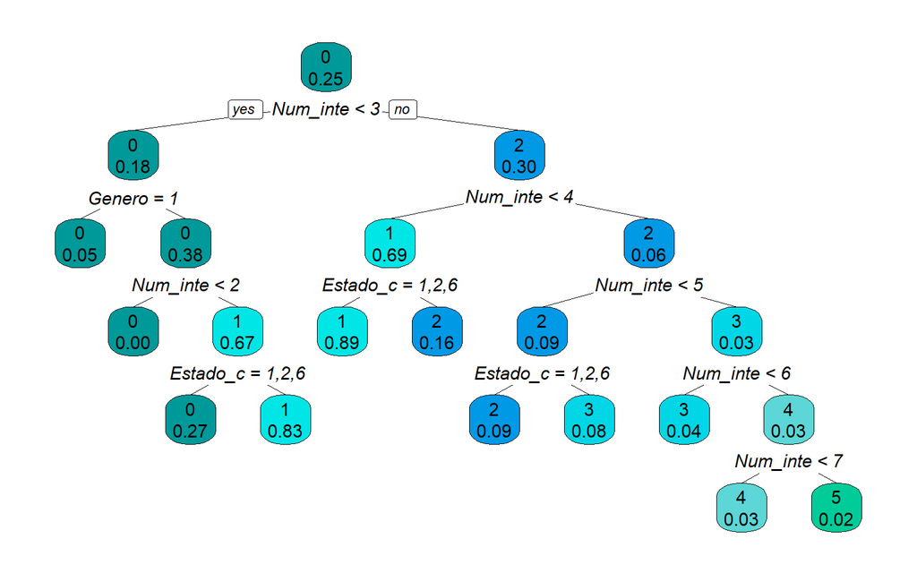

Se observa que la variable Num_integrantes es una de las más importantes, en la creación del árbol de clasificación.

Se hacen las predicciones y se obtiene la siguiente matriz de confusión

| Predicciones | Reales 0 | Reales 1 | Reales 2 | Reales 3 | Reales 4 | Reales 5 |
| --- | --- | --- | --- | --- | --- | --- |
| 0 | 6188 | 333 | 0 | 0 | 0 | 0 |
| 1 | 410 | 3795 | 148 | 0 | 0 | 0 |
| 2 | 176 | 483 | 3287 | 60 | 0 | 0 |
| 3 | 91 | 122 | 444 | 1583 | 163 | 0 |
| 4 | 13 | 28 | 73 | 182 | 458 | 54 |
| 5 | 6 | 7 | 27 | 49 | 133 | 486 |

La tasa de acierto es 0.8403107 y la tasa de error es 0.1596893

### Árboles de Regresión

```r
mod1_reg_arboles <- rpart(as.numeric(as.character(Num_hijos))~., data = trn_prop)
```

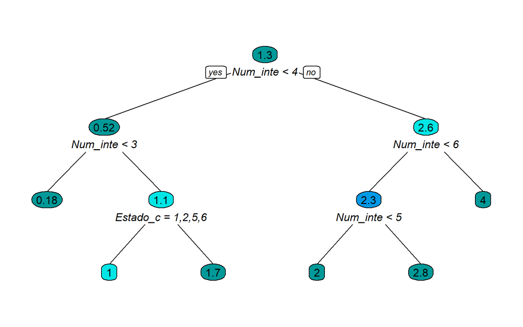

Se observa que en la construcción del árbol de regresión solo se utilizaron dos variables, Num_integrantes y Estado_civil.

Se hacen las predicciones y se obtiene la matriz de confusión

| Predicciones | Reales 0 | Reales 1 | Reales 2 | Reales 3 | Reales 4 | Reales 5 |
| --- | --- | --- | --- | --- | --- | --- |
| 0 | 6407 | 1425 | 0 | 0 | 0 | 0 |
| 1 | 285 | 2756 | 317 | 0 | 0 | 0 |
| 2 | 140 | 483 | 3264 | 455 | 0 | 0 |
| 3 | 33 | 69 | 298 | 1188 | 163 | 0 |
| 4 | 19 | 35 | 100 | 231 | 591 | 540 |

La tasa de acierto es 0.7556785 y la tasa de error es 0.2443215

### Regresión Poisson

Se ajusta el modelo usando la función gamlss del paquete gamlss, con una familia Poisson.

```r
HijosPoisson <-gamlss(as.numeric(as.character(Num_hijos))~., data= trn_prop, family=PO(mu.link="log"))
```

```
## GAMLSS-RS iteration 1: Global Deviance = 170257.6
## GAMLSS-RS iteration 2: Global Deviance = 170257.6
```

Se hacen las predicciones y obtenemos la matriz de confusión

| Predicciones | Reales 0 | Reales 1 | Reales 2 | Reales 3 | Reales 4 | Reales 5 |
| --- | --- | --- | --- | --- | --- | --- |
| -2 | 62 | 0 | 0 | 0 | 0 | 0 |
| -1 | 4464 | 365 | 27 | 1 | 0 | 0 |
| 0 | 2326 | 4272 | 3270 | 333 | 19 | 0 |
| 1 | 30 | 126 | 670 | 1525 | 696 | 221 |
| 2 | 1 | 5 | 11 | 13 | 36 | 268 |
| 3 | 0 | 0 | 1 | 2 | 3 | 43 |
| 4 | 1 | 0 | 0 | 0 | 0 | 4 |
| 5 | 0 | 0 | 0 | 0 | 0 | 4 |

```r
acierto<-sum(diag(MC3))/sum(MC3)
error <- 1-acierto
```

### Bosque Aleatorio

Se ajusta un Bosque Aleatorio con la función ranger

```r
mod_RF <- ranger(
  Num_hijos~.,
  data = (trn_prop),
  num.trees = 500, # número de árboles
  mtry = 5, # numero de variables a utilizar en cada árbol
  max.depth = 8, # profundidad de cada árbol
  importance = 'impurity'
)
```

Se hacen las predicciones y se obtiene la matriz de confusión

| Predicciones | Reales 0 | Reales 1 | Reales 2 | Reales 3 | Reales 4 | Reales 5 |
| --- | --- | --- | --- | --- | --- | --- |
| 0 | 6254 | 207 | 9 | 0 | 0 | 0 |
| 1 | 426 | 3996 | 145 | 1 | 0 | 0 |
| 2 | 127 | 428 | 3336 | 77 | 1 | 1 |
| 3 | 58 | 90 | 385 | 1512 | 42 | 1 |
| 4 | 13 | 35 | 72 | 223 | 539 | 9 |
| 5 | 6 | 12 | 32 | 61 | 172 | 529 |

La tasa de acierto es 0.8599394 y la tasa de error es 0.1400606

### Naive Bayes

Se ajusta un clasficador por el método de Bayes ingenuo

```r
mod_Naive_Bayes <- naiveBayes(Num_hijos ~ ., data = trn_prop)
```

Se hacen las predicciones y se obtiene la matriz de confusión

| Predicciones | Reales 0 | Reales 1 | Reales 2 | Reales 3 | Reales 4 | Reales 5 |
| --- | --- | --- | --- | --- | --- | --- |
| 0 | 5909 | 1342 | 35 | 0 | 0 | 0 |
| 1 | 830 | 3003 | 999 | 29 | 0 | 0 |
| 2 | 96 | 319 | 2547 | 426 | 0 | 0 |
| 3 | 38 | 80 | 332 | 1258 | 364 | 10 |
| 4 | 9 | 18 | 52 | 143 | 335 | 193 |
| 5 | 2 | 6 | 14 | 18 | 55 | 337 |

La tasa de acierto es 0.7122187 y la tasa de error es 0.2877813

### Knn

Antes de aplicar el modelo se deben organizar las variables, como se muestra a continuación.

Conversión de las variables categoricas a variables dummy

```r
library(dummies)

# Conjunto de entrenamiento
Base_KNN_dummy_trn <- dummy.data.frame(data=data.frame(trn_prop[ ,-6]))
Base_KNN_dummy_trn <- cbind(Base_KNN_dummy_trn,"Num_hijos" = trn_prop$Num_hijos)

# Conjunto de prueba
Base_KNN_dummy_tst <- dummy.data.frame(data=tst_prop[ ,-6])
Base_KNN_dummy_tst <- cbind(Base_KNN_dummy_tst,"Num_hijos" = tst_prop$Num_hijos)
```

Se normalizan las Variables Numéricas

```r
#Conjunto de entrenamiento
datos_c_trn <- Base_KNN_dummy_trn
datos_c_trn[,c(1,10)] <- scale(datos_c_trn[,c(1,10)]) # normalización

#Conjunto de prueba
datos_c_tst <- Base_KNN_dummy_tst
datos_c_tst[,c(1,10)] <- scale(datos_c_tst[,c(1,10)])
```

Conjuntos de entrenamiento y test

```r
train <- datos_c_trn[ ,-14] # crea train sin la variable respuesta
test <- datos_c_tst[ ,-14] # crea test sin la variable respuesta

y_train <- datos_c_trn[ ,14]
y_test <- datos_c_tst[ ,14]
```

Con el fin de elegir un K apropiado se entrena el modelo variando el K entre 1 y 30, después se escoge el que mejor se ajusta al conjunto de entrenamiento.

```r
modelo <- train.kknn(Num_hijos ~ ., data = datos_c_trn, kmax = 30)
```

Con el k óptimo que es igual a 18 se ajusta el modelo knn, se hacen las predicciones y se obtiene la matriz de confusión

```r
knn_model <- knn(train, test, cl = y_train, k = 18)
```

| Predicciones | Reales 0 | Reales 1 | Reales 2 | Reales 3 | Reales 4 | Reales 5 |
| --- | --- | --- | --- | --- | --- | --- |
| 0 | 6285 | 221 | 21 | 7 | 2 | 0 |
| 1 | 442 | 3984 | 152 | 1 | 0 | 0 |
| 2 | 107 | 434 | 3346 | 97 | 3 | 0 |
| 3 | 40 | 91 | 369 | 1517 | 78 | 2 |
| 4 | 7 | 30 | 68 | 207 | 535 | 43 |
| 5 | 3 | 8 | 23 | 45 | 136 | 495 |

La tasa de acierto es 0.8597266 y la tasa de error es 0.1402734.

## Conclusión del ajuste de modelos

Los modelos escogidos son de regresión y clasificación, en cada uno se adaptó la variable respuesta. En los de clasificación se obtienen las predicciones como el número de hijos puntual, en los de regresión se obtienen aproximaciones decimales las cuales previamente debían ser redondeadas para ser comparadas con los valores reales, en general por este último procedimiento se podía notar que funcionaban mucho mejor en los modelos de clasificación (su tasa de aciertos era la más alta) por lo tanto finalmente estos fueron considerados como los favoritos y continuaron en el proceso de selección de modelos, además, cabe aclarar que a cada modelo le fue ingresado las variables como se debía según su proceso de ajuste, por ejemplo, en el modelo de Knn las variables explicativas fueron ingresadas, estandarizadas las que son numéricas y se crearon variables dummy para las categóricas, en general el desempeño de este modelo fue muy bueno, pero su tiempo de ejecución fue superior al de los otros; este es uno de los criterios utilizados en la selección.

# Resultados

## Selección del mejor modelo

Para comparar la eficiencia de los modelos se crea una matriz en la cual se almacenará las tasas de acierto de los modelos que se construyeron en el paso anterior

```r
df <- matrix(rep(NA,80), nrow=20, ncol=4)
df <- data.frame(df)
colnames(df) <- c("Arbol_clasificacion","RandomForest", "NaiveBayes", "Knn")
```

Para llenar la matriz anterior se realiza un for que ejecuta cada uno de los modelos 20 veces, escogiendo aleatoriamente el conjunto de entrenamiento y el conjunto de prueba

```r
for(i in 1:20){

  set.seed(i) # Semilla

  # Se saca una muestra de entrenamiento que conserve las proporciones en la varaible Num_hijos

  trn_prop <- Base_modelar_f %>%
    mutate(
      var_indx = 1:dim(Base_modelar_f)[1]
    ) %>%
    group_by(Num_hijos) %>%
    sample_frac(0.8, replace = F)

  # Se saca la muestra de test con las que no fueron seleccionadas en la muestra de
  # train
  tst_prop <- Base_modelar_f[-trn_prop$var_indx, ]

  # Se elimina la variable de índice
  trn_prop$var_indx <- NULL

  trn_prop <- trn_prop[sample(1:dim(trn_prop)[1]), ]
  tst_prop <- tst_prop[sample(1:dim(tst_prop)[1]), ]

    # Ajuste de los modelos

  ## Árbol de clasificación
  arbol_clasificacion <- rpart(Num_hijos~., data = trn_prop)
  pred_arbol_clasificacion <-  predict(arbol_clasificacion, newdata = tst_prop, type=
                                         "class")

  tasa_arbol_clasificacion <- matriz_confusion(pred_arbol_clasificacion,
                                               tst_prop$Num_hijos)

  # Modelo RF
  RF <- ranger(Num_hijos~.,  data = (trn_prop),   num.trees = 100,  mtry = 5,
               max.depth = 8,  importance = 'impurity')


  pred_RF <- predict(RF, data = (tst_prop))

  tasa_RF <- matriz_confusion(pred_RF$predictions, tst_prop$Num_hijos)

  ## Naive Bayes

  Naive_Bayes <- naiveBayes(Num_hijos ~ ., data = trn_prop)
  pred_Naive_Bayes <- predict(Naive_Bayes, newdata = tst_prop, type="class")

  tasa_Naive_Bayes <- matriz_confusion(pred_Naive_Bayes, tst_prop$Num_hijos)


  ## Knn

  # Conjunto de entrenamiento
  Base_KNN_dummy_trn <- dummy.data.frame(data=data.frame(trn_prop[ ,-6]))
  Base_KNN_dummy_trn <- cbind(Base_KNN_dummy_trn,"Num_hijos" = trn_prop$Num_hijos)
  # Conjunto de prueba
  Base_KNN_dummy_tst <- dummy.data.frame(data=tst_prop[ ,-6])
  Base_KNN_dummy_tst <- cbind(Base_KNN_dummy_tst,"Num_hijos" = tst_prop$Num_hijos)

  #Conjunto de entrenamiento
  datos_c_trn <- Base_KNN_dummy_trn
  datos_c_trn[,c(1,10)] <- scale(datos_c_trn[,c(1,10)])

  #Conjunto de prueba
  datos_c_tst <- Base_KNN_dummy_tst
  datos_c_tst[,c(1,10)] <- scale(datos_c_tst[,c(1,10)])

  # Separación de la variable respuesta
  train <- datos_c_trn[ ,-14] # crea train sin la variable respuesta
  test <- datos_c_tst[ ,-14] # crea test sin la variable respuesta
  y_train <- datos_c_trn[ ,14]
  y_test <- datos_c_tst[ ,14]
  pred_knn <- knn(train, test, cl = y_train, k = 20)

  tasa_knn <- matriz_confusion(pred_knn, y_test)

  tasas <- c(tasa_arbol_clasificacion, tasa_RF, tasa_Naive_Bayes, tasa_knn)

  df[i,] <- tasas

}
```

|  | Arbol_clasificacion | RandomForest | NaiveBayes | Knn |
| --- | --- | --- | --- | --- |
| 1 | 0.84280 | 0.86150 | 0.715600 | 0.861000 |
| 2 | 0.84260 | 0.86240 | 0.717300 | 0.860900 |
| 3 | 0.83990 | 0.85970 | 0.719800 | 0.856900 |
| 4 | 0.83690 | 0.85800 | 0.708100 | 0.858200 |
| 5 | 0.84250 | 0.86500 | 0.713500 | 0.864400 |
| 6 | 0.84180 | 0.86360 | 0.721000 | 0.860600 |
| 7 | 0.84110 | 0.86040 | 0.717700 | 0.858600 |
| 8 | 0.84170 | 0.86240 | 0.709900 | 0.858700 |
| 9 | 0.84210 | 0.86350 | 0.713700 | 0.861900 |
| 10 | 0.83940 | 0.86310 | 0.715300 | 0.861100 |
| 11 | 0.84730 | 0.86760 | 0.717200 | 0.863900 |
| 12 | 0.84220 | 0.86220 | 0.722300 | 0.860700 |
| 13 | 0.84320 | 0.86410 | 0.721600 | 0.862600 |
| 14 | 0.84350 | 0.86670 | 0.709800 | 0.867500 |
| 15 | 0.83990 | 0.86030 | 0.713800 | 0.857200 |
| 16 | 0.83970 | 0.86330 | 0.708600 | 0.860800 |
| 17 | 0.83980 | 0.86160 | 0.712200 | 0.858500 |
| 18 | 0.84220 | 0.86060 | 0.715300 | 0.859200 |
| 19 | 0.84140 | 0.86140 | 0.710000 | 0.860500 |
| 20 | 0.84160 | 0.86040 | 0.708800 | 0.860700 |
| Media | 0.84158 | 0.86239 | 0.714575 | 0.860695 |

Bosques aleatorios se escogió ya que no solo presenta una de las tasas de acierto más altas entre todos los modelos desarrollados, sino que a su vez permite reducir la dimensionalidad del conjunto de datos, ya que este valoraba y utilizaba 5 variables tanto para la modelación, como para la predicción, además de que estas variables no tienen valores faltantes permitiendo contar con el conjunto de datos completo que es una cantidad muy apreciable de registros.

Como último filtro, se busca reducir el número de árboles que se utilizó en el proceso anterior. Para esto se hace una prueba cambiando el tamaño del bosque a 100 árboles en lugar de 500

```r
RF <- ranger(Num_hijos~.,  data = (trn_prop),   num.trees = 100,  mtry = 5,
             max.depth = 8,  importance = 'impurity')
pred_RF <- predict(RF, data = (tst_prop))
tasa_RF <- matriz_confusion(pred_RF$predictions, tst_prop$Num_hijos)
```

La tasa de acierto tanto con 100 y 500 árboles es de aproximadamente 0.86, es decir, el tamaño del bosque no representa un cambio significativo a la hora de predecir, por lo que se decide implementar el modelo con 100 árboles.

## Ajuste del modelo final con todas las observaciones

Con el fin de presentar el modelo al público se hace uso de todos los registros para su entrenamiento.

```r
RandomForest <- ranger(Num_hijos~.,  data = Base_modelo,   num.trees = 100,  mtry = 5,
             max.depth = 8,  importance = 'impurity')
```

# Prueba de Escritorio

A continuación se darán los datos que corresponden a la información de cada uno de los investigadores

```r
require(ranger)
# datos de los investigadores
# Nombre <- c(Num_integrantes, Estado_civil, Genero, Edad, Vive_hogar_madre)
Miguel <- c(3, 6, 1, 52, 2)
Jennifer <- c(4, 2, 2, 43, 3)
Juan <- c(4, 6, 1, 59, 2)
Cristina <- c(3, 2, 2, 50, 2)
Salome <- c(3, 4, 2, 53, 3)

# Poniendo los datos en un data.frame para realizar predicciones
df <- rbind(Miguel, Jennifer, Juan, Cristina, Salome) #Unión de los datos
df <- data.frame(df) #Conversión a data.frame

# Nombres de las variables
colnames(df) <- c("Num_integrantes",
                  "Estado_civil",
                  "Genero",
                  "Edad",
                  "Vive_hogar_madre")


prediccion <- predict(RandomForest, df) # Predicción con el Random Forest
prediccion$predictions # Imprime las predicciones
```

```
## [1] 1 2 2 1 2
## Levels: 0 1 2 3 4 5
```

| Inverstigador | Valores_predichos | Valores_Reales |
| --- | --- | --- |
| Miguel | 1 | 1 |
| Jennifer | 2 | 2 |
| Juan | 2 | 2 |
| Cristina | 1 | 1 |
| Salome | 2 | 2 |

# Conclusiones

- En general aunque algunas veces la información no este explicita en los lugares a los que tenemos acceso, gracias a los métodos de aprendizaje estadístico podemos deducirla.
- En el mundo estadístico los Bosques Aleatorios son considerados por algunos como la panacea para los problemas de clasificación, en este problema se ve que este tipo de modelos es el que presenta mejores resultados, además, es un modelo parsimonioso, que se puede llevar a la práctica y presenta buenos resultados.
- A partir del número de variables que finalmente se obtuvo, da referencia a que se puede obtener información de la variable respuesta sin necesidad de tener en cuenta tantas variables como las que se consideraron inicialmente, esto realmente es algo bueno, ya que no se requiere mucha información para obtener buenos resultados y a la hora de requerir recolectar nueva información será un proceso más sencillo, esto es a lo que llamamos modelos parsimoniosos los cuales siempre serán el mejor resultado.
- Mediante los análisis realizados en el informe anterior cabe resaltar que muchas veces un hogar puede estar representado y ser estudiado de manera correcta a partir de información que viene principalmente del jefe de hogar y ser verídica.
- Dado que los resultados con los métodos de Random forest fueron muy buenos se recomienda para futuros estudios ensayar modelo tipo boosting.
- La predicción del número de hijos tiene bastantes utilidades en diferentes sectores por ejemplo en el caso de una inmobiliaria, que quiere arrendar una nueva propiedad y dejarla en manos de la familia ideal. La inmobiliaria no quiere invadir e incomodar la privacidad de sus clientes; pero con poca información y con ayuda de esta aplicación la inmobiliaria podrá saber cuántos de los futuros integrantes de este hogar son hijos y así saber un poco más sobre la familia que se mudará a la casa.
- Cabe resaltar que en un inicio cuando se entrenaban los modelo para clasificar el número de hijos de 0 a 14, si bien los modelos basados en arboles presentaban un tiempo de ejecución corto estos solo eran capaces de predecir de 0 a 6 hijos, comparado con el modelo Knn que fue el único de los modelos probados capaz de predecir en las 14 clases.

# Bibliografía

- Bonilla Jaime, G., & Garcia Valdez, E. (2009). Impacto de las condiciones socioeconomicas familiares en las decisiones de fertilidad (numero de hijos), utilizando un modelo de regresión poisson: período de estudio 2005-2006 (Bachelor’s thesis).
- Forero, Nohora, & Gamboa, Luis Fernando. (2009). Family Size in Colombia: Guessing or Planning? Intended vs. Actual Family Size in Colombia. Desarrollo y Sociedad, (64), 85-118. Retrieved March 31, 2021, Recuperada de http://www.scielo.org.co/scielo.php?script=sci_arttext&pid=S0120-35842009000200004&lng=en&tlng=en.
- García, D. & Jaramillo, A. (6 de Enero de 2019). El cambio social que se gesta en los hogares colombianos. El Tiempo. https://www.eltiempo.com/economia/sectores/que-implica-que-los-hogares-colombianos-sean-mas-pequenos-analisis-censo-2018-311776
- Robayo, E. P. (2019). Tipología del hogar en Colombia (2000-2015): Características Sociodemográficas de las mujeres. (Tesis de Maestría, Universidad Externado de Colombia). Recuperada de https://bdigital.uexternado.edu.co/bitstream/001/2223/1/DKA-spa-2019-Tipologias_de_hogar_en_Colombia_2000_2015_caracteristicas_sociodemograficas_de_las_mujeres
- Wright, M. N. & Ziegler, A. (2017). ranger: A fast implementation of random forests for high dimensional data in C++ and R. J Stat Softw 77:1-17. https://doi.org/10.18637/jss.v077.i01.